# Building fMRI Regressors

Bradley R. Buchsbaum

2026-10-03

## Introduction: What is a Regressor?

In fMRI analysis, a **regressor** (or predictor) represents the expected BOLD signal timecourse associated with a specific experimental condition or event type. It’s typically created by convolving a series of event onsets (often represented as delta functions or “sticks”) with a hemodynamic response function (HRF).

`fmrihrf` provides the `regressor()` function to easily create these objects from event timings and an HRF. While these regressor objects are often constructed automatically by modeling functions in other packages, this vignette explores how to create and manipulate them directly, offering finer control over the model components.

## Basic Regressor from Event Onsets

Suppose we have a simple event-related fMRI design with stimuli presented every 12 seconds. We want to model these events using the SPM canonical HRF (`HRF_SPMG1`). The events are brief, so we model them with a duration of 0 seconds (instantaneous).

```r
# Define event onsets
onsets <- seq(0, 10 * 12, by = 12)

# Create the regressor object
# Uses HRF_SPMG1 by default if no hrf is specified
# Duration is 0 by default
reg1 <- regressor(onsets = onsets, hrf = HRF_SPMG1)

# Access components using helper functions
head(onsets(reg1))
```

```
#> [1]  0 12 24 36 48 60
```

```r
nbasis(reg1)
```

```
#> [1] 1
```

The regressor is the convolution of the event train with the HRF. Each event contributes one copy of the HRF, starting at its onset, and overlapping copies add up. Here the next event arrives while the previous response is still in its undershoot, so every peak after the first is slightly lower. Each copy is added only over the HRF’s `span` (24 s for `HRF_SPMG1`), so where the undershoot is cut off there is a tiny step, about 1.5% of the peak, visible on fine grids.

Throughout these vignettes, grey marks inputs, events and reference curves, and coloured lines are HRFs or regressors. The one exception: when regressors with different events share a panel (as in the shifted regressor below), each regressor’s events are marked in its own colour.

The HRF above is scaled to a peak of 1 to show its shape. Unscaled, `HRF_SPMG1` peaks at about 0.175, the height of the first regressor peak in the next figure (later peaks are about 0.16, lowered by the previous undershoot).

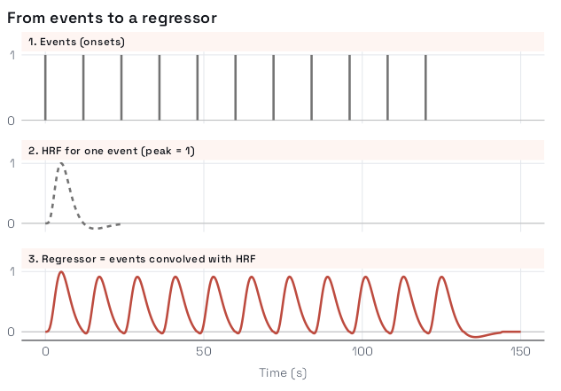

## Evaluating and Plotting a Regressor

A `regressor` object stores the event information but doesn’t automatically compute the timecourse. To get the predicted BOLD signal at specific time points (e.g., corresponding to scan acquisition times), we use the `evaluate()` function.

```r
# Define a time grid corresponding to scan times (e.g., TR=2s)
TR <- 2
scan_times <- seq(0, 140, by = TR)

# One value per scan
head(evaluate(reg1, scan_times))
```

```
#> [1] 4.650473e-06 3.679907e-02 1.556004e-01 1.601994e-01
#> [5] 9.016183e-02 3.213275e-02
```

`plot_regressors()` draws the continuous prediction on a fine grid and, with `samples`, the values the model actually uses at each scan. Grey bars under the curve mark the events. (`plot(reg1)` gives a quick base-graphics view of the same regressor.)

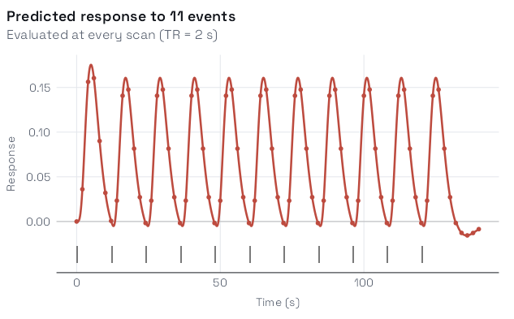

The curve is the modeled response; dots are its values at the scan times (TR = 2 s); grey bars mark event onsets.

```r
plot_regressors(reg1, grid = seq(0, 140, by = 0.1), samples = scan_times,
                labels = "SPMG1 regressor",
                title = "Predicted response to 11 events",
                subtitle = "Evaluated at every scan (TR = 2 s)")
```

## Varying Event Durations

Sometimes events have different durations. The `duration` argument in `regressor()` can take a vector matching the length of `onsets`.

```r
# Example onsets and durations
onsets_var_dur <- seq(0, 5 * 12, length.out = 6)
durations_var <- 1:length(onsets_var_dur) # Durations increase from 1s to 6s

# Create regressor with varying durations
reg_var_dur <- regressor(onsets_var_dur, HRF_SPMG1, duration = durations_var)

scan_times_dur <- seq(0, max(onsets_var_dur) + 30, by = TR)
fine_grid_dur <- seq(0, max(scan_times_dur), by = 0.1)
```

The width of each grey bar is the event’s duration. Longer events produce larger responses:

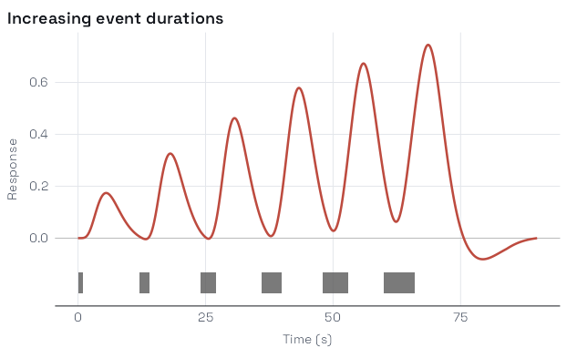

```r
plot_regressors(reg_var_dur, grid = fine_grid_dur,
                labels = "Durations 1-6 s",
                title = "Increasing event durations")
```

### Duration and Summation

By default (`summate=TRUE`), the predicted response accumulates if events overlap or have extended duration. Setting `summate=FALSE` averages over each event’s duration instead, so the peak amplitude no longer grows with duration.

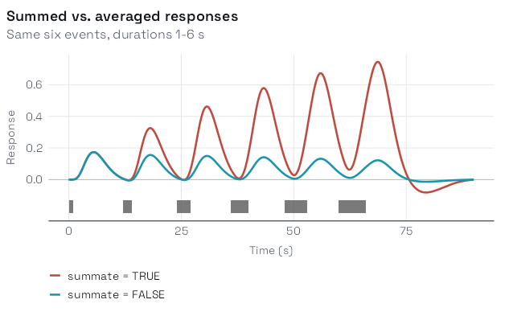

```r
# Create regressor with varying durations, summate=FALSE
reg_var_dur_nosum <- regressor(onsets_var_dur, HRF_SPMG1,
                               duration = durations_var, summate = FALSE)

# Compare summating vs non-summating using plot_regressors()
plot_regressors(reg_var_dur, reg_var_dur_nosum,
                labels = c("summate = TRUE", "summate = FALSE"),
                grid = fine_grid_dur,
                title = "Summed vs. averaged responses",
                subtitle = "Same six events, durations 1-6 s")
```

## Varying Event Amplitudes (Parametric Modulation)

We can model variations in event intensity or some associated parameter by providing an `amplitude` vector. This creates a *parametric regressor* where the height of the HRF for each event is scaled by the corresponding amplitude value.

```r
# Example onsets and amplitudes (e.g., representing task difficulty)
onsets_amp <- seq(0, 10 * 12, length.out = 11)
amplitudes_raw <- 1:length(onsets_amp)

# It's common practice to center the modulator
amplitudes_scaled <- scale(amplitudes_raw, center = TRUE, scale = FALSE)

# Create the parametric regressor
reg_amp <- regressor(onsets_amp, HRF_SPMG1, amplitude = amplitudes_scaled)

# The centred amplitudes run from -5 to 5; the middle event has amplitude 0
drop(amplitudes_scaled)
```

```
#>  [1] -5 -4 -3 -2 -1  0  1  2  3  4  5
#> attr(,"scaled:center")
#> [1] 6
```

Each event now contributes an HRF scaled by its amplitude, so early events (negative amplitudes) produce dips and late events peaks. The event with amplitude 0 contributes nothing (`regressor()` drops it):

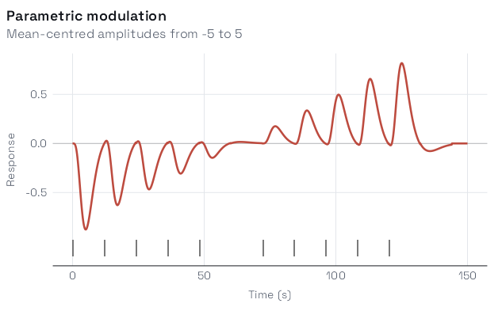

```r
fine_grid_amp <- seq(0, max(onsets_amp) + 30, by = 0.1)
plot_regressors(reg_amp, grid = fine_grid_amp,
                labels = "Amplitude-modulated",
                title = "Parametric modulation",
                subtitle = "Mean-centred amplitudes from -5 to 5")
```

## Continuous Features

A sampled feature such as RMS energy is a time series, not a list of trials. `feature_regressor()` encodes each sample as a zero-order-hold bin of width `dt` and convolves that signal with the HRF. That is the same linear model as amplitude modulation on this sampling grid: the predicted BOLD is $Hx$.

By default the series is demeaned before convolution (`center = TRUE`) and left in native units. For a whole-run series that is $H(x-\mu 1)=Hx-\mu H1$. In the interior of the run, overlapping HRFs make $H1$ nearly constant, so with a GLM intercept the centered and raw columns test the same effect. They differ by the HRF-length ramp of $H1$ at the run boundaries; centering removes that onset/offset transient. `scale = "sd"` z-scores the feature, not the final filtered design column.

```r
dt <- 0.1
feat_times <- seq(0, 20, by = dt)
# Simulated acoustic envelope
rms <- abs(sin(2 * pi * feat_times / 8)) * (0.5 + 0.5 * sin(2 * pi * feat_times / 20))

feat <- feature_regressor(rms, dt = dt, hrf = HRF_SPMG1)
```

The top panel is the feature after centring, the input to the convolution; the bottom panel is the predicted BOLD response. The response lags the feature by several seconds and smooths it. Because the feature is centred, its quiet second half is below its mean, and the response dips well below zero around 20 s; that trough comes from centring, not from the HRF undershoot:

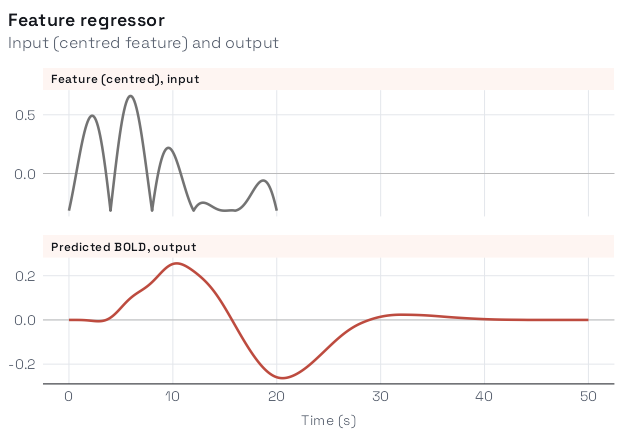

```r
feat_grid <- seq(0, max(feat_times) + 30, by = 0.1)
feat_df <- rbind(
  data.frame(time = feat_times, value = rms - mean(rms),
             panel = "Feature (centred), input"),
  data.frame(time = feat_grid, value = evaluate(feat, feat_grid, precision = dt),
             panel = "Predicted BOLD, output")
)
feat_df$panel <- factor(feat_df$panel, levels = unique(feat_df$panel))
ggplot(feat_df, aes(time, value, colour = panel)) +
  geom_hline(yintercept = 0, colour = "grey70", linewidth = 0.3) +
  geom_line(linewidth = 0.9) +
  facet_wrap(~panel, ncol = 1, scales = "free_y") +
  scale_colour_manual(values = c("grey45", hrf_palette(1))) +
  scale_y_continuous(breaks = function(l) {
    b <- pretty(l, n = 3)
    b[b >= l[1] & b <= l[2]]
  }) +
  labs(title = "Feature regressor", subtitle = "Input (centred feature) and output",
       x = "Time (s)", y = NULL) +
  theme(legend.position = "none", strip.text = element_text(hjust = 0),
        plot.title.position = "plot")
```

Using `regressor(times, amplitude = rms, duration = 0)` instead would treat each sample as a unit-mass impulse and scale the predicted BOLD by about `1/dt`. Pass `duration = dt` (and skip centering) if you need the same ZOH encoding from `regressor()`.

If you want intensity *conditional on an on-period*, pass a `mask` for those samples (off-period stays 0 after centering) and a separate boxcar for presence. That is not an affine transform of the all-sample series. Do not drop off-period samples before centering: that silently turns the all-sample model into the sparse one.

## Combining Duration and Amplitude Modulation

You can provide both `duration` and `amplitude` vectors to model events that vary in both aspects.

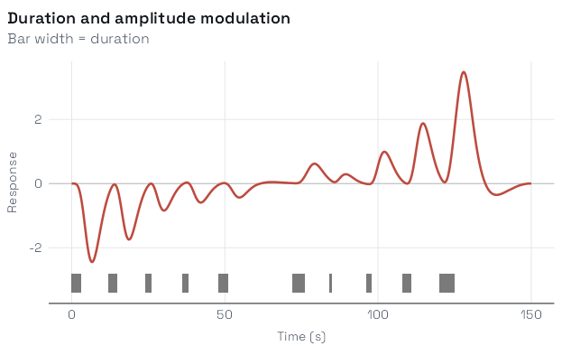

```r
set.seed(123)
onsets_comb <- seq(0, 10 * 12, length.out = 11)
amps_comb <- scale(1:length(onsets_comb), center = TRUE, scale = FALSE)
durs_comb <- sample(1:5, length(onsets_comb), replace = TRUE)

reg_comb <- regressor(onsets_comb, HRF_SPMG1,
                      amplitude = amps_comb, duration = durs_comb)

fine_grid_comb <- seq(0, max(onsets_comb) + 30, by = 0.1)
plot_regressors(reg_comb, grid = fine_grid_comb,
                labels = "Duration and amplitude",
                title = "Duration and amplitude modulation",
                subtitle = "Bar width = duration")
```

## Regressors with HRF Basis Sets

If you use an HRF object with multiple basis functions (e.g., `HRF_SPMG3`, `HRF_BSPLINE`), the `regressor` object will represent multiple timecourses, one for each basis function. `evaluate()` will return a matrix.

```r
# Use a B-spline basis set
onsets_basis <- seq(0, 10 * 12, length.out = 11)
hrf_basis <- HRF_BSPLINE # Uses N=5 basis functions by default

reg_basis <- regressor(onsets_basis, hrf_basis)
nbasis(reg_basis) # Should be 5
```

```
#> [1] 5
```

```r
# Evaluate - this returns a matrix
scan_times_basis <- seq(0, max(onsets_basis) + 30, by = TR)
pred_basis_matrix <- evaluate(reg_basis, scan_times_basis)
dim(pred_basis_matrix) # rows = time points, cols = basis functions
```

```
#> [1] 76  5
```

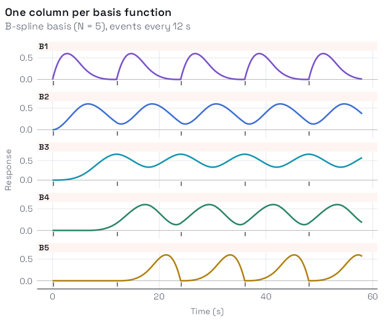

```r
plot_regressors(reg_basis, grid = seq(0, 58, by = 0.1), layout = "stack",
                title = "One column per basis function",
                subtitle = "B-spline basis (N = 5), events every 12 s")
```

## Shifting Regressors

You can temporally shift all onsets within a regressor using the `shift()` method.

```r
# Original regressor
reg_orig <- regressor(onsets = c(10, 30, 50), hrf = HRF_SPMG1)

# Shifted regressor (delay by 5 seconds)
reg_shifted <- shift(reg_orig, shift_amount = 5)

onsets(reg_orig)
```

```
#> [1] 10 30 50
```

```r
onsets(reg_shifted) # Onsets are now 15, 35, 55
```

```
#> [1] 15 35 55
```

The bars mark each regressor’s onsets in its own colour; the whole response moves 5 seconds later without changing shape:

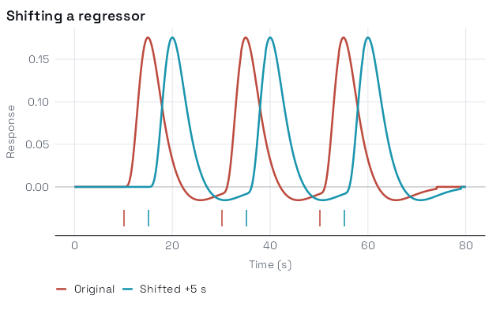

```r
plot_regressors(reg_orig, reg_shifted,
                labels = c("Original", "Shifted +5 s"),
                grid = seq(0, 80, by = 0.1),
                show_onsets = TRUE,  # Show onsets for both
                title = "Shifting a regressor")
```